# Diving Performance Analysis

Charlotte Friedman

2025-12-01

# Project Overview

- **Goal:** Use past meet results to understand which types of dives are:
  - scoring best, and most consistent.

  **Approach:**
  - Scrape my DiveMeets profile
  - Clean and categorize dives / Summarize performance by dive group
  - Build a small **Shiny app** to explore results interactively

# The Data

From my DiveMeets “Dive Statistics” page:

- One row per **unique dive + board** (e.g., 103B on 1m)
- Columns:
  - Dive code & description
  - **Highest score** ever
  - **Average score** across meets
  - **# of times** I’ve competed that dive

# Cleaning & Structuring

To make the data useful, I:

- Removed extra header rows embedded in the HTML table
- Fixed columns where:
  - High score, average score, and counts were misaligned
  - Converted scores and counts from text to numeric
- Created a **dive group** variable from the first digit of the dive code:
  - 1 = Forward, 2 = Back, 3 = Reverse, 4 = Inward, 5 = Twist

# Which Groups Score Best?

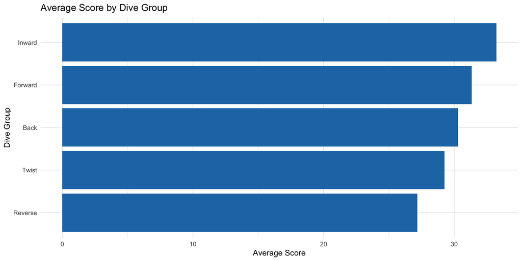

# Consistency & Volume

# Shiny Interactive Explorer

I built a small **Shiny app** to make this analysis explorable:

- Dropdown to choose a **dive group** (Forward, Back, etc.)
- Bar chart updates to show:
  - Average score for each dive in that group
  - My best-scoring dives within each group
  - Which dives I might want to emphasize or retire

# Shiny Interactive Explorer (continued)

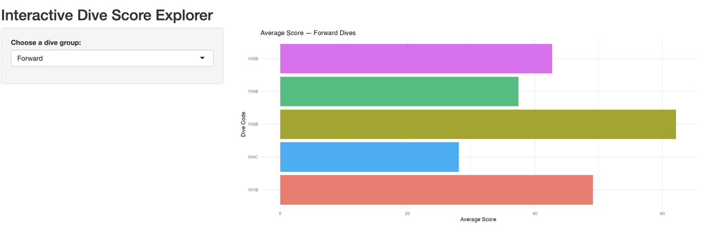

Shiny interface with bar chart of dive scores

# Key Takeaways

- Web scraping + cleaning turned a messy website table into a usable dataset.
- Summaries by dive group show where I’m currently strongest and weakest.
- The Shiny app adds **interactivity**, so coaches/athletes can explore “what if” questions themselves.
- This workflow can be updated each season to track progress over time.